# Лабораторная работа №1

Подготовка лабораторного стенда

Устинова В. В.

Российский университет дружбы народов, Москва, Россия

12 сентября 2026

# Информация

## Докладчик

- Устинова Виктория Вадимовна
- студент НПИбд-01-24
- Российский университет дружбы народов

## Цели

Приобретение практических навыков установки Rocke Linux на виртуальную машину с помощью инструмента Vagrant

## Задание

1. Сформируйте box-файл с дистрибутивом Rocky Linux для VirtualBox
2. Запустите виртуальные машины сервера и клиента и убедитесь в их работоспособ- ности.
3. Внесите изменения в настройки загрузки образов виртуальных машин server и client, добавив пользователя с правами администратора и изменив названия хостов
4. Скопируйте необходимые для работы с Vagrant файлы и box-файлы виртуальных машин на внешний носитель. Используя эти файлы, вы можете попробовать развернуть виртуальные машины на другом компьютере.

# Выполнение лабораторной работы

## Подготовка рабочего каталога проекта

Создать рабочий каталог для проекта vagrant и разместить в нем образ Rocke Linux HCL-файла makefileи подкаталоги http и scripts. Это подготавливает основу для сборки box-файла

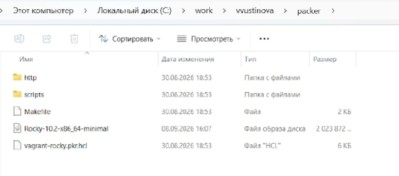

В каталоге находятся папки http, scripts и файлы Makefile, Rocky-10.2-x86_64-minimal.iso, vagrant-rocky.pkr.hc

## Скрипт

Внести изменения в настройки внутреннего окружения машин, добавив пользователя с правами администратора через скрипт 01-user.sh. Скрипт создаёт пользователя, задаёт пароль и добавляет его в группу wheel

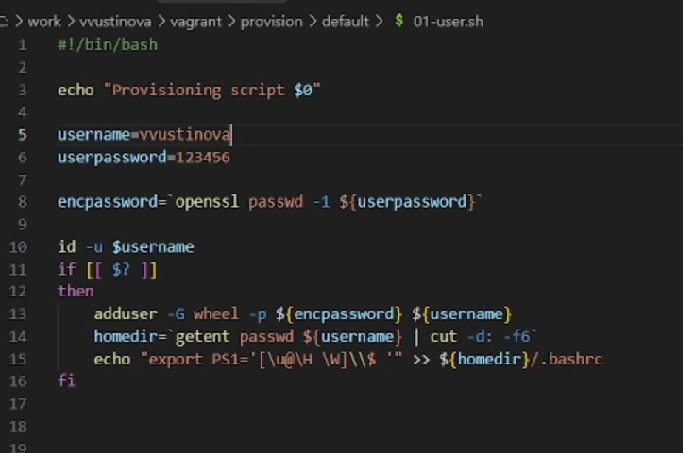

Скрипт создаёт пользователя vvustinova и добавляет его в группу wheel.

## box file

Сформировать box-файл с Rocky Linux для VirtualBox с помощью Packer. Выполняется инициализация плагинов и сборка образа; для QEMU сборка завершается ошибкой, для VirtualBox продолжается.

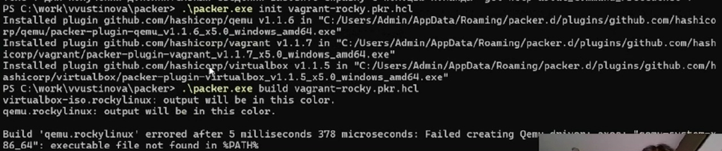

Запущена сборка box-файла через packer.exe; для QEMU — ошибка, для VirtualBox — процесс идёт.

## box file

Зарегистрировать созданный box-файл в Vagrant командой vagrant box add, чтобы его можно было использовать для запуска машин. После этого box-файл распаковывается и становится доступным

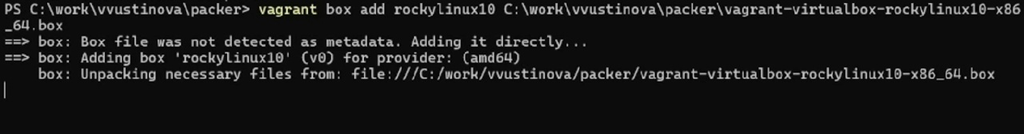

Выполнена команда vagrant box add rockylinux10, box-файл добавлен и распакован.

## Запуск сервера и клиента

Запустить виртуальные машины сервера и клиента через провайдер VirtualBox. Перед запуском устанавливается плагин vagrant-vbguest, затем поднимаются обе машины.

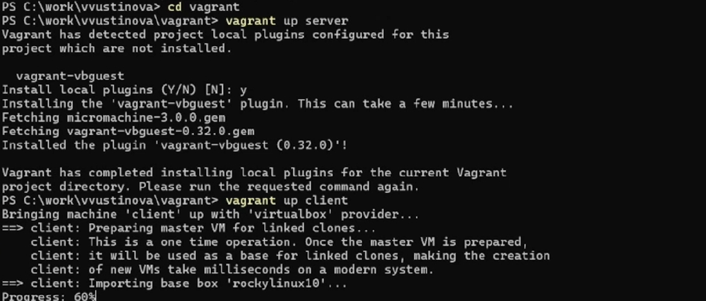

Установлен плагин vagrant-vbguest, затем запущены сервер и клиент.

## Проверка состояния виртуальных машин.

Убедиться в работоспособности запущенных машин с помощью команды vagrant status. Обе машины должны находиться в состоянии running

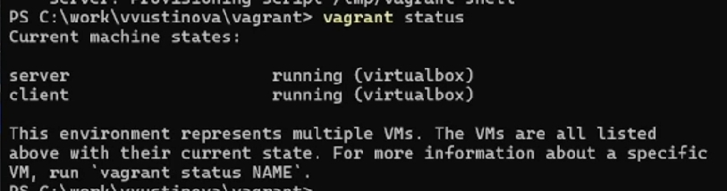

vagrant status показывает, что server и client — в состоянии running

## Переключение на пользователя на сервере.

Подключиться к серверу и перейти под созданного пользователя командой su - vvustinova. После успешного входа приглашение меняется на vvustinovaserver.vvustinova.net

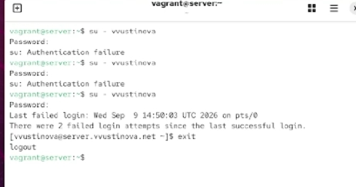

Выполнен вход su - vvustinova на сервере, приглашение сменилось на vvustinovaserver.vvustinova.net

## Переключение на пользователя на клиенте.

Подключиться к клиенту и перейти под созданного пользователя командой su - vvustinova. После успешного входа приглашение отображается как vvustinova@client.vvustinova.net

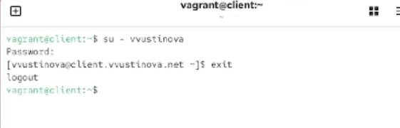

Выполнен вход su - vvustinova на клиенте, приглашение — vvustinova@client.vvustinova.net

## Остановка машин и применение провижининга.

Выключить машины и зафиксировать изменения внутренних настроек. Сначала выполняется vagrant halt, затем запуск сервера с –provision для применения скриптов

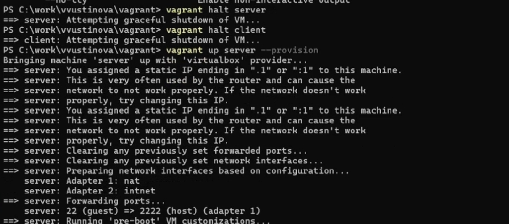

Выполнены vagrant halt server и vagrant halt client, затем запущен vagrant up server –provision.

## Выводы

В ходе работы были приобретены практические навыки установки Rocky Linux на виртуальную машину с помощью Vagrant. Освоены основные команды инструмента, принципы работы с box-файлами, HCL-файлами и конфигурационным файлом Vagrantfile. Успешно сформирован box-файл, запущены виртуальные машины сервера и клиента, добавлен пользователь с правами администратора и настроены названия хостов.